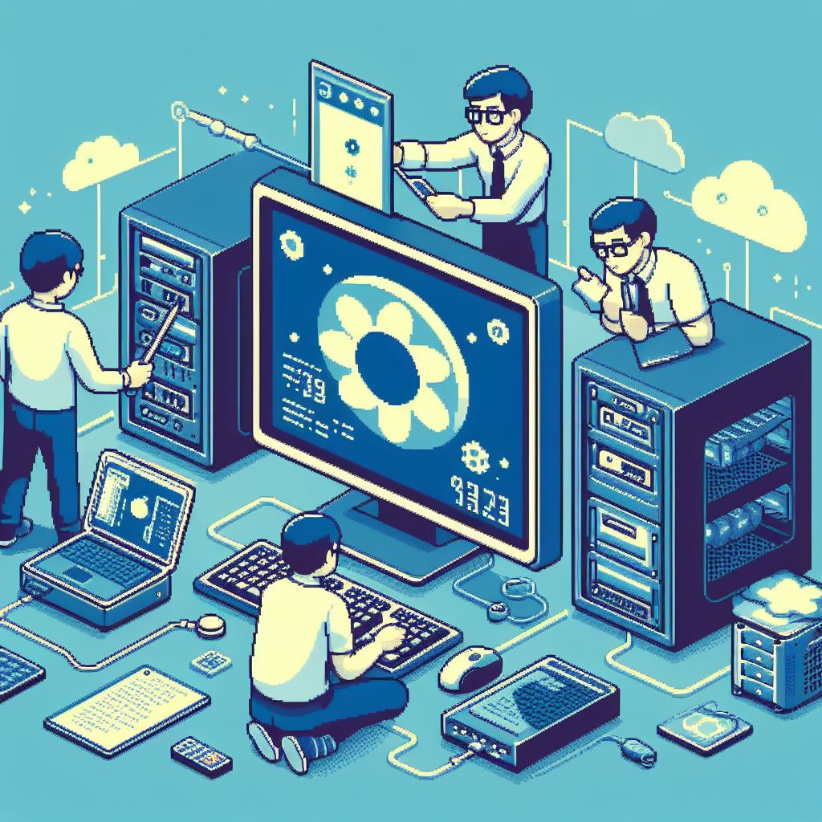

# Primer: Environment Setup

Setting up your computational environment for the AY2024-25 project

This page runs through the process of setting up a computing environment similar to that you will need for your AY2024-25 project.

**Prerequisites**

This primer assumes the following:

- **you are working on your own computer** (e.g. a laptop/desktop machine)
- **you are able to start a terminal window** (e.g. `Terminal` on a Mac or Linux machine, or in Windows Subsystem Linux)

You should either **be familiar with the command-line or have worked through the Software Carpentries shell lesson**:

- [SWC Shell lesson](https://swcarpentry.github.io/shell-novice/)

The primer walks through the following steps:

1. Downloading the SIPBSCompBiol project template repository
2. Creating and activating a `conda` environment for your project
3. Installing the `ncbi-genome-download` package and using it to download a set of genomes

## 1 Set up a project folder from a template

**Note**

Please read the Noble (2009) and Sandve *et al.* (2013) papers at the Ten Great Papers page, and the `README.md` file at the template repository to understand the principles behind the organisation of this template.

- [Ten Great Papers](https://widdowquinn.github.io/ten_great_papers/)
- [Bioinformatics project template](https://sipbs-compbiol.github.io/template_bioinformatics_project/)
- [Noble (2009)](http://doi.org/10.1371/journal.pcbi.1000424)
- [Sandve *et al.* (2013)](http://doi.org/10.1371/journal.pcbi.1003285)

### 1.1 Download and extract the project template

1. Use your browser to visit the project template repository at https://github.com/sipbs-compbiol/template_bioinformatics_project.
2. Click on the small triangle at the right of the green `Code` button to see the download options for the template.

[figure not shown]

Context menu for the `Code` download button

3. Click on `Download ZIP` to download a `.zip` format compressed file containing the repository template to your own computer, in the usual way you would download a file using your browser. This will place a file called `template_bioinformatics_project-master.zip` into that location.

**Where should I save this file?**

When you uncompress the repository template, it will expand into the full set of folders and subfolders. You can move this folder tree *after* you have uncompressed the file, or you can move the `.zip` file to the directory where you want to keep the project files (e.g. under `Documents` on a Mac), and uncompress it there. The choice is yours.

4. Uncompress the file (e.g. by double-clicking on a Mac). This will produce a folder called `template_bioinformatics_project-master` in the same folder as the compressed file.

**Make sure you acturally uncompress the file**

Some operating systems, such as Windows, allow you to work with compressed files *as if they had been uncompressed* without *actually* uncompressing them.

**You do need to fully uncompress the repository template to work with it.**

5. Start a terminal and navigate to the top-level folder in the repository template.

**Tip**

I saved the `.zip` file in the `Documents` folder on my computer, and uncompressed that file in the same location. My project template is therefore in the `~/Documents/template_bioinformatics_project-master` directory. I can navigate to this location using the `cd` command, and check the contents using the command `ls`.

[**NOTE**: The `%` symbol is the command prompt, *not* part of the command itself. This may look different on your computer (e.g. it might be a dollar sign: `$`).]

```bash
% cd ~/Documents/template_bioinformatics_project-master
% ls
LICENSE      README.md    _config.yml  assets/      data/        docs/        notebooks/   results/     scripts/
```

## 2 Create and activate a `conda` environment for your project

**Warning**

Before beginning this part of the guide, you should make yourself familiar with the `conda` documentation at the link below:

- [`conda` tutorial](https://docs.conda.io/projects/conda/en/latest/user-guide/getting-started.html)

**You will need to have already installed the `conda` package for your operating system.**

On Mac and Linux, this is usually a straightforward software installation, and you can follow the instructions at the link below:

- [Installing Anaconda on Mac and Linux](https://docs.anaconda.com/free/anaconda/install/index.html)

On Windows, you *must* distinguish between installing Anaconda under Windows, and installing it under WSL (Windows Subsystem Linux). You will be using WSL for your project, and you **must** install `conda` within WSL (WSL *cannot* see the version of `conda` installed under the Windows operating system; in any case the software that runs on a Linux OS will not typically run on a Windows OS). There are several online guides to help with this.

- [Installing Conda/Anaconda in WSL](https://www.how2shout.com/how-to/install-anaconda-wsl-windows-10-ubuntu-linux-app.html)
- [Installing Miniconda in WSL](https://kontext.tech/article/1064/install-miniconda-and-anaconda-on-wsl-2-or-linux)
1. Create a new `conda` environment by issuing the command below.

```bash
% conda create --name bm954_project -y
```

**Breaking down the components of the command line**

As above, the `%` symbol is the *command prompt* - not part of the command itself. You do not type this when entering and running your command.

- `conda`: you are running the `conda` program and instructing it to carry out an action
- `create`: this is the action you are instructing `conda` to undertake, to *create* a new environment
- `--name bm954_project`: this *option* tells `conda` what name the new environment is to be known by; you can choose any name you like, and do not have to use `bm954_project` if you would prefer to use something else. However, it is usually a good idea to name the environment such that you can tell immediately what it is used for
- `-y`: this answers all the optional questions about installation which `conda` might ask with “*yes*”
2. Activate the new `conda` environment you have just created by issuing the command below (if you called your environment something other than `bm954_project`, then use that name instead, here).

```bash
% conda activate bm954_project
```

You should notice that the left-most part of your command prompt changes from `(base)` to `(bm954_project)` (or whatever name you used for your environment).

**How to check what environments are available**

You can use the command `conda info --envs` (demonstrated below) to list all the environments that your installation of `conda` is aware of:

```bash
% conda info --envs
# conda environments:
#
base                     /Users/lpritc/opt/anaconda3
2022_david               /Users/lpritc/opt/anaconda3/envs/2022_david
2022_nora                /Users/lpritc/opt/anaconda3/envs/2022_nora
algo_2022_py39           /Users/lpritc/opt/anaconda3/envs/algo_2022_py39
aoc2021                  /Users/lpritc/opt/anaconda3/envs/aoc2021
aoc2022                  /Users/lpritc/opt/anaconda3/envs/aoc2022
aoc2023                  /Users/lpritc/opt/anaconda3/envs/aoc2023
bm432_py310              /Users/lpritc/opt/anaconda3/envs/bm432_py310
bm954_project         *  /Users/lpritc/opt/anaconda3/envs/bm954_proj
[...]
```

## 3 Install `ncbi-genome-download` and recover some genomes

One of the main advantages of `conda` is that it handles technical issues of *package management* (the process of installing and configuring software tools) and makes using them much easier. The typical command we might use would be `conda install <PROGRAM NAME>` where `<PROGRAM NAME>` is replaced by the name of the software you want to install.

In particular, `conda` is a common software distribution route for bioinformatics software, through the `conda` *channel* called [`bioconda`](https://bioconda.github.io/).

**Important**

In order to use `bioconda` on your computer, you will need to configure the channel.

### 3.1 Configuring the `bioconda` channel

**Warning**

Before installing `bioconda` you should be awware of the information at the link below:

- [`bioconda` tutorial](https://bioconda.github.io/tutorials/index.html)

To set up the `bioconda` channel on your computer, you should follow the instructions at the [`bioconda` website](https://bioconda.github.io/), and issue the four commands below, in sequence:

```bash
conda config --add channels defaults
conda config --add channels bioconda
conda config --add channels conda-forge
conda config --set channel_priority strict
```

You only need to do this once on your computer, and `bioconda` will then be available in any environment you create.

### 3.2 Installing `ncbi-genome-download`

To install the `ncbi-genome-download` package, we use the `conda install` command, as noted above. This will take a short while to download and configure all the *dependencies* of the tool (packages that need to be installed for the software to run). The process you see in the terminal should resemble that shown below.

```bash
 % conda install ncbi-genome-download -y
 Channels:
 - conda-forge
 - bioconda
 - defaults
Platform: osx-64
Collecting package metadata (repodata.json):
[...]
The following NEW packages will be INSTALLED:

  appdirs            conda-forge/noarch::appdirs-1.4.4-pyh9f0ad1d_0
[...]
  xz                 conda-forge/osx-64::xz-5.2.6-h775f41a_0



Downloading and Extracting Packages:

Preparing transaction: done
Verifying transaction: done
Executing transaction: done
```

Once this is complete, the `ncbi-genome-download` program should be available to you. You can test this by asking the software for its help guide, using the command `ncbi-genome-download -h` as demonstrated below:

```bash
% ncbi-genome-download -h
usage: ncbi-genome-download [-h] [-s {refseq,genbank}] [-F FILE_FORMATS] [-l ASSEMBLY_LEVELS] [-g GENERA] [--genus GENERA]
                            [--fuzzy-genus] [-S STRAINS] [-T SPECIES_TAXIDS] [-t TAXIDS] [-A ASSEMBLY_ACCESSIONS]
                            [--fuzzy-accessions] [-R REFSEQ_CATEGORIES] [--refseq-category REFSEQ_CATEGORIES] [-o OUTPUT]
                            [--flat-output] [-H] [-P] [-u URI] [-p N] [-r N] [-m METADATA_TABLE] [-n] [-N] [-v] [-d] [-V]
                            [-M TYPE_MATERIALS]
                            groups
[...]
```

### 3.3 Downloading a set of genome sequences

**Warning**

Before downloading genomes, you should familiarise yourself with the information at the links below:

- [NCBI Assembly Level definitions](https://www.ncbi.nlm.nih.gov/datasets/docs/v2/glossary/#assembly-level)
- [`ncbi-genome-download` documentation](https://github.com/kblin/ncbi-genome-download/blob/master/README.md)
- [NCBI genome file formats](https://www.ncbi.nlm.nih.gov/datasets/docs/v2/reference-docs/file-formats/)

For your project, you will want to download all complete genome sequences for a single genus of bacteria. This section of the guide will illustrate that process for the genus *Dickeya*.

The command to download all genomes of a single named genus of bacteria is `ncbi-genome-download --genera "<GENUS>" bacteria`, where `<GENUS>` is replaced by the actual name of the genus you want to download.

To restrict downloaded genomes only to those that are *complete*, we use the option `--assembly-levels complete`.

To download all available sequence data, including GBFF (annotated) and FASTA (sequence data only) we need to use the option `--formats all`

If we wanted the program to keep us informed about what it was doing, we would ask it to be *verbose* by using the option `--verbose` or `-v`

Putting this together to download genomes for the genus *Dickeya* we would use the command as demonstrated below:

```bash
% ncbi-genome-download --assembly-levels complete --genera "Dickeya" --formats all --verbose bacteria
```

This will place the downloaded genomes into individual subdirectories, under the subdirectory `refseq`. These genome are compressed using the `gzip` program. We can tell this because the filnames end in `.gz`.

```bash
 % tree refseq
refseq
└── bacteria
    ├── GCF_000147055.1
    │   ├── GCF_000147055.1_ASM14705v1_assembly_report.txt
    │   ├── GCF_000147055.1_ASM14705v1_assembly_stats.txt
    │   ├── GCF_000147055.1_ASM14705v1_cds_from_genomic.fna.gz
    │   ├── GCF_000147055.1_ASM14705v1_feature_table.txt.gz
    │   ├── GCF_000147055.1_ASM14705v1_genomic.fna.gz
    │   ├── GCF_000147055.1_ASM14705v1_genomic.gbff.gz
    │   ├── GCF_000147055.1_ASM14705v1_genomic.gff.gz
    │   ├── GCF_000147055.1_ASM14705v1_protein.faa.gz
    │   ├── GCF_000147055.1_ASM14705v1_protein.gpff.gz
    │   ├── GCF_000147055.1_ASM14705v1_rna_from_genomic.fna.gz
    │   ├── GCF_000147055.1_ASM14705v1_translated_cds.faa.gz
[...]
```

The downloaded files are in a number of different formats, and you will not need to use all of them in your project.

## 4 Summary

This page provided a gude to setting up your project analogously to preparing your bench for laboratory work.

You first used a template to set up your project’s folder structure, which is a little like making sure you have a well-organised work area.

You then installed `conda` and set up a new environment for your project, which plays a similar role to making your your bench is clean and practising a kind of “aseptic technique” for making sure that installed bioinformatics tools don’t conflict with each other.

You then installed `ncbi-genome-download` and obtained a set of bacterial genomes directly from NCBI. This is similar to acquiring a set of strains from a collection, and having them ready to work with on your benchtop.

Your next steps using these genomes will be to prepare them so that they can be used in your experiments.